# Lab 4A

Principal Components Analysis

2026

# Getting Started: Loading the Dataset

Before you begin the practical, you need to load the required dataset into R. To ensure a smooth workflow, please follow one of the two options below:

**Option 1: Using a Dedicated Folder**

Create a specific folder for this assignment and place the dataset file inside it. You can then load the data using the `load()` function by specifying the correct file path. (Note for Windows users: Please ensure you change all backslashes `\` in your copied file path to forward slashes `/` in R).

For **Mac** users, your path will look like this:

```r
load("/Users/your_username/Documents/folder_name/dataset_name.RData")
```

For **Windows** users, your path will look like this:

```r
load("C:/Users/your_username/Documents/folder_name/dataset_name.RData")
```

**Option 2: Using an R Project**

Create an R Project (`.Rproj`) for this assignment and store the dataset directly within that project folder. Make sure to open RStudio by double-clicking the `.Rproj` file. This automatically sets your working directory, allowing you to load the dataset directly without a long path:

```r
load("dataset_name.RData")
```

**Note for this specific lab:** Please ensure you have downloaded all four required dataset files (tumor.Rdata, Profession.RData, novels.Rdata, and faces.RData) from the course environment into your working directory before proceeding.

In this lab, you will use Principal Component Analysis (PCA) in three different settings:

- personality test data
- text data represented as a bag of words
- face images

PCA is a dimension reduction technique that summarizes a large set of correlated variables by a smaller number of components that capture the main patterns of variation in the data.

You will need the packages `psych`, `dplyr`, `randomForest`, and `tidytext`, and the datasets `tumor.Rdata`, `Profession.Rdata`, `novels.Rdata`, and `faces.RData` (bonus dataset).

**Show Answer**

```r
library(psych)
library(dplyr)
library(tidytext)
```

# Prediction with PCs

Although PCA is an unsupervised learning method,its component scores can be used as input variables in supervised prediction models. This allows us to reduce the number of predictors while keeping the main information in the data.

In this exercise, we train a logistic regression model on the principal component scores of the `tumor` data and compare the confusion matrix on the test data with those of the tree, random forest, boosting, and SVM models from the previous lab.

1. Load the `tumor` data, and make the same indices for the training set as in the previous lab.

   **Hint:** Setting seed and creating a 75/25 train-test split for the tumor data.

**Show Answer**

```r
load("tumor.Rdata")
set.seed(1)
train     <- sample(nrow(tumor), .75 * nrow(tumor))
```

2. Perform a PCA on the data with six components and save the the PCA object.

   **Hint:** Use `principal(data, nfactor = 6)`.

**Show Answer**

```r
# Performing PCA extracting exactly 6 principal components.
pca <- principal(tumor[, -1], nfactor = 6)
```

3. Add the six component score variables to the `tumor` data.

   **Hint:** Use `pca$scores`.

**Show Answer**

```r
tumor <- data.frame(tumor, pca$scores)
```

4. Fit a logistic regression model on the training set using the first six principal component scores as predictors. Display the summary of the model.

   Interpret the coefficients of `RC4` and `RC6`. To do so, use the loadings of the original variables on these two components to explain what a higher score on `RC4` or `RC6` represents in terms of the original tumor features. Note that coefficient of `RC4` and `RC6` tells whether higher component scores increase or decrease the probability of diagnosis.loadings tell which original variables define that component. Together, these explain which tumor characteristics are associated with the outcome.

   **Hint:** First determine whether the coefficient is positive or negative. Then use the loadings to identify which original variables have large contributions to that component.

**Show Answer**

```r
# Fitting a logistic regression using ONLY the 6 principal components
fit <- glm(
  diagnosis ~ RC1 + RC2 + RC3 + RC4 + RC5 + RC6,
  family = binomial,
  data = tumor[train, ]
)

summary(fit)
```

```
##
## Call:
## glm(formula = diagnosis ~ RC1 + RC2 + RC3 + RC4 + RC5 + RC6,
##     family = binomial, data = tumor[train, ])
##
## Coefficients:
##             Estimate Std. Error z value Pr(>|z|)
## (Intercept)  -0.4699     0.3487  -1.348  0.17771
## RC1           9.5671     1.6714   5.724 1.04e-08 ***
## RC2           1.1155     0.4967   2.246  0.02470 *
## RC3          -0.8376     0.3797  -2.206  0.02738 *
## RC4           2.9844     0.5736   5.203 1.96e-07 ***
## RC5           3.2204     0.6104   5.276 1.32e-07 ***
## RC6           1.0633     0.3411   3.117  0.00183 **
## ---
## Signif. codes:  0 '***' 0.001 '**' 0.01 '*' 0.05 '.' 0.1 ' ' 1
##
## (Dispersion parameter for binomial family taken to be 1)
##
##     Null deviance: 558.572  on 425  degrees of freedom
## Residual deviance:  62.116  on 419  degrees of freedom
## AIC: 76.116
##
## Number of Fisher Scoring iterations: 9
```

5. Compute the predicted probabilities for the observations in the test set. Then classify each observation as `"M"` or `"B"` using a cutoff of 0.5, and display the confusion matrix. Compare the performance of the logistic regression model with the tree, random forest, boosting, and SVM models from the previous lab.

   **Hint:** Focus on the number of correctly and incorrectly classified malignant (`"M"`) and benign (`"B"`) tumors.

**Show Answer**

```r
# Generating test-set predictions and evaluating model accuracy using the PC-based model
pred <- data.frame(prob = predict(fit, tumor[-train, ], "response")) %>%
  mutate(class = case_when(prob > .5 ~ "M",
                           .default = "B"))

cf <- function(obs = tumor[-train, "diagnosis"], est) table(obs, est)
cf(est = pred$class)
```

```
##    est
## obs  B  M
##   B 85  1
##   M  2 55
```

# Personality types

The file `Profession.Rdata` contains the dataset `Profession`, with preference scores of 5389 subjects on 48 professions.

The 48 professions are grouped into 6 sets of 8 items. Each set is intended to measure a different personality type. For example, items `R1` to `R8` correspond to the personality type **R = Realistic (Doers)**. The codebook for the dataset is provided in `Profession.txt`. The aim of this analysis is to examine whether PCA can recover one principal component for each of the six personality types.

1. Load the data file `Profession.Rdata`, and display the scree plot for the `Profession` data. The scree plot helps decide how many principal components to keep by showing how much variance each component explains. How many principal components does the plot suggest?

   **Hint:** Use `VSS.scree()` and look at PCs with an eigenvalue > 1.

**Show Answer**

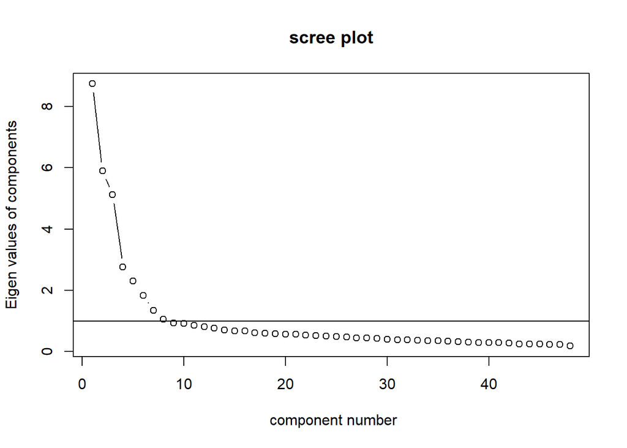

```r
load("Profession.RData")
# Display the scree plot to assess how many components to retain
VSS.scree(Profession)
```

2. There seem to be 7 or 8 PCs with an eigenvalue > 1, but because we want a solution distinguishing between 6 personality types we will ignore the 7th and 8th component. Conduct a PCA that extracts 6 factors without rotation.

   **Hint:** Use the `principal()` function again, setting `nfactors = 6` and `rotate = "none"`.

**Show Answer**

```r
# Extracting 6 unrotated components to match the theoretical 6 personality types
prof_pca <- principal(Profession, nfactors = 6, rotate = "none")
```

3. Display the `loadings` of the first 6 components with the function `print()`, and set the cutoff to 0.4. Do the loadings correspond to the personality types?

   **Hint:** Use `print()` and wrap the `loadings()` of your PCA object inside it, specifying the `cutoff = 0.4` argument.

**Show Answer**

```r
print(loadings(prof_pca), cutoff = 0.4)
```

```
##
## Loadings:
##    PC1    PC2    PC3    PC4    PC5    PC6
## R1  0.487
## R2  0.521
## R3  0.412
## R4  0.529        -0.421
## R5  0.497
## R6  0.532        -0.416
## R7  0.563
## R8  0.547
## I1                       0.432
## I2         0.417
## I3         0.409 -0.484
## I4  0.421
## I5               -0.500  0.432
## I6  0.400  0.450 -0.422
## I7  0.417        -0.503  0.414
## I8  0.440        -0.489
## A1         0.537
## A2         0.598
## A3         0.493
## A4         0.606
## A5         0.609
## A6         0.539
## A7
## A8         0.536
## S1                0.444
## S2
## S3                0.441
## S4
## S5                0.538
## S6                0.454
## S7                0.407
## S8
## E1  0.405                             -0.462
## E2                0.421
## E3  0.529
## E4                0.404
## E5  0.486
## E6  0.443         0.488
## E7  0.405                             -0.451
## E8  0.514
## C1  0.501 -0.474
## C2  0.559 -0.415
## C3  0.555 -0.503
## C4  0.509 -0.455
## C5  0.514
## C6  0.555
## C7  0.533 -0.430
## C8  0.590 -0.491
##
##                  PC1   PC2   PC3   PC4   PC5   PC6
## SS loadings    8.736 5.895 5.114 2.757 2.307 1.839
## Proportion Var 0.182 0.123 0.107 0.057 0.048 0.038
## Cumulative Var 0.182 0.305 0.411 0.469 0.517 0.555
```

4. Rerun the PCA using the default `varimax` rotation, and display the rotated component loadings. Note that, rotation is used to improve interpretation of the components. The `varimax` rotation keeps the components uncorrelated and tries to make each variable load strongly on one component and weakly on the others. Did the rotation help in distinguishing between the personality types?

   **Hint:** Run `principal()` exactly as before but either omit the `rotate` argument or explicitly set `rotate = "varimax"`.

**Show Answer**

```r
# Varimax rotation maximizes the variance of loadings, pushing them toward 0 or 1, making PCs much easier to interpret
prof_rot <- principal(Profession, nfactors = 6)

print(loadings(prof_rot), cutoff = 0.4)
```

```
##
## Loadings:
##    RC1    RC5    RC4    RC2    RC3    RC6
## R1         0.502
## R2         0.771
## R3         0.640
## R4         0.642
## R5         0.744
## R6         0.784
## R7         0.723
## R8         0.806
## I1                0.629
## I2                0.693
## I3                0.818
## I4                0.668
## I5                0.855
## I6                0.761
## I7                0.825
## I8                0.575
## A1                       0.709
## A2                       0.759
## A3                       0.620
## A4                       0.783
## A5                       0.751
## A6                       0.740
## A7
## A8                       0.711
## S1                              0.592
## S2                              0.651
## S3                              0.742
## S4                              0.481
## S5                              0.795
## S6                              0.670
## S7                              0.705
## S8                              0.728
## E1                                     0.676
## E2                                     0.602
## E3                                     0.642
## E4                                     0.524
## E5                                     0.575
## E6                                     0.717
## E7                                     0.694
## E8                                     0.456
## C1  0.758
## C2  0.660
## C3  0.815
## C4  0.775
## C5  0.733
## C6  0.673
## C7  0.667
## C8  0.786
##
##                  RC1   RC5   RC4   RC2   RC3   RC6
## SS loadings    5.158 4.710 4.647 4.254 4.146 3.733
## Proportion Var 0.107 0.098 0.097 0.089 0.086 0.078
## Cumulative Var 0.107 0.206 0.302 0.391 0.477 0.555
```

5. It appears that A7 does not really belong to any of the the PC’s. Check the question, and try to explain why.

   **Hint:** Look at the item description for A7 in the codebook. Consider whether “performing stunts” aligns with typical artistic traits.

**Show Answer**

```r
# Is performing stunts really something that artistic persons would like to do?
# A7 likely measures a risk-taking or physical trait rather than a purely artistic one, causing it to fall out of the core components.
```

6. Rename the PCs in the names of the personality types in the code book (e.g. Doers, Thinkers, etc), and save the result.

   **Hint:** Extract the scores using `as.data.frame(your_pca_object$scores)`, then use `names()` or `colnames()` to assign the new names.

**Show Answer**

```r
# Renaming the components to match the theoretical psychological traits for easier downstream interpretation
d <- as.data.frame(prof_rot$scores)
names(d) <- c("Organizer", "Doer", "Thinker", "Creator", "Helper", "Persuader")
```

7. Display the scores of a random sample of 5 persons from the data, and interpret this persons personality profile.

   **Hint:** Use `sample()` to randomly select 5 rows from your renamed scores dataframe. Then use `round(..., 1)` to format the output.

**Show Answer**

```r
# Displaying the latent personality profiles (component scores) for 5 random individuals
d[sample(5389, 5), ] %>%  round(1)
```

```
##      Organizer Doer Thinker Creator Helper Persuader
## 4141      -0.4 -0.7     0.4    -0.1    0.7       1.7
## 4208      -0.5 -0.1     0.9     1.1    0.1      -1.4
## 5147       0.9  0.2     1.2    -1.1   -2.2       0.6
## 5036      -0.5 -1.4     1.0     1.0   -0.8       0.7
## 4318       0.2 -0.1    -0.2    -1.5   -0.6      -0.1
```

# Text analysis

Before applying PCA, the raw text data must first be converted into a data frame in which the rows correspond to novels (identified by author and title) and the columns correspond to stopwords. This format makes the data suitable for PCA. Note that stopwords are very common words (e.g. *the*, *and*, *of*). They usually carry little meaning, but their frequencies can still help distinguish writing styles.

We will do this step by step.

1. Load the `novels.Rdata`, and display a contingency table of the `title` and `author` to check its content.

   **Hint:** The function `xtabs()` can be used to create a contingency table.

**Show Answer**

```r
load("novels.Rdata")
# Cross-tabulating novels and authors to understand the dataset's structure
xtabs(~ title + author, novels)
```

```
##                              author
## title                         Austen, Jane Brontë, Anne Brontë, Charlotte
##   Agnes Grey                             0         6985                 0
##   Emma                               16488            0                 0
##   Jane Eyre: An Autobiography            0            0             21001
##   Pride and Prejudice                14199            0                 0
##   Sense and Sensibility              12673            0                 0
##   Shirley                                0            0             25520
##   The Professor                          0            0              9413
##   The Tenant of Wildfell Hall            0        18477                 0
##   Villette                               0            0             21312
##   Wuthering Heights                      0            0                 0
##                              author
## title                         Brontë, Emily
##   Agnes Grey                              0
##   Emma                                    0
##   Jane Eyre: An Autobiography             0
##   Pride and Prejudice                     0
##   Sense and Sensibility                   0
##   Shirley                                 0
##   The Professor                           0
##   The Tenant of Wildfell Hall             0
##   Villette                                0
##   Wuthering Heights                   12342
```

2. Create a new variable `authnov` by combining a short version of the author name and a short version of the title, separated by an underscore. Before abbreviating the title, remove common words such as “The”, “and”, and “of”. Then remove the original variables `author` and `title`.

   **Hint:** Use `mutate()` to modify `author` and `title` step by step. The function `gsub()` can be used to remove common words from the title, `abbreviate()` to create short labels, `paste()` to combine author and title into `authnov`, and `select()` to drop the original variables.

   **Note:** A warning may appear because some author names contain accented characters (such as ë in Brontë). This does not affect the analysis.

**Show Answer**

```r
# Cleaning titles by removing common filler words and creating a unique author_title identifier
novels <- novels %>%

  mutate(title    = gsub("The | and | of |: An Autobiography| ", "", title),
                  # removing words and spaces from the titles
         title    = abbreviate(title, 10, F),
                  # abbreviating the title to the 1st 10 characters
         author   = abbreviate(author, 2),
                  # abbreviating the author's' names to the 1st letters of the surname and name
         authnov  = paste(author, title, sep= "_")) %>%
  dplyr::select(-author, -title)
```

3. Create a data frame `wordfreq` containing the frequency of each word for each novel label `authnov`.

   **Hint:** First convert the text into individual words using `unnest_tokens()`. Then group the data by `authnov` and `word`, and count the number of occurrences with `summarize()` and `n()`.

**Show Answer**

```r
wordfreq <- novels %>%

  unnest_tokens(word, text) %>%           # split text into individual words

  mutate(word = gsub("_", "", word)) %>%  # remove underscores from tokens if present

  group_by(authnov, word) %>%             # group by novel label and word

  summarize(freq = n(), .groups = "keep") # count how often each word appears
```

4. Replace the variable `freq` in `wordfreq` by `relfreq`, denoting the relative appearance of the words per `authnov` category.

   **Hint:** Use `mutate()` to create a `total` column with `sum(freq)`, then calculate `relfreq = freq / total`. Finally, use `dplyr::select()` to remove `freq` and `total`.

**Show Answer**

```r
# Normalizing frequencies by novel length to ensure fair comparisons between short and long books
wordfreq <- wordfreq %>%

  group_by(authnov) %>%

  mutate(total   = sum(freq),

         relfreq = freq / total) %>%

  dplyr::select(-freq, -total)
```

**Show Answer**

```r
# Defining a custom lexicon of structural stopwords to analyze writing style rather than plot content
stopwords <- data.frame(word = c("a", "the", "of", "and", "to", "in",
                                "for", "have", "i", "you", "she"))
```

6. Remove all words from `wordfreq` that are not included in `stopwords`, and save the result as `stopfreq`.

   **Hint:** Use `semi_join()` to keep only the matching words.

**Show Answer**

```r
# Filtering the dataset to retain ONLY the target stylistic stopwords
stopfreq <- wordfreq %>%

  semi_join(., stopwords, by = "word")
```

7. Transform `stopfreq` into a data frame `words` in which the rows correspond to `authnov` and the columns correspond to the stopwords. The entries of the table should contain the relative word frequencies.

   **Hint:** Use `pivot_wider()` to reshape the data from long to wide format, and `column_to_rownames()` to use `authnov` as row names.

**Show Answer**

```r
# Reshaping data from long to wide format so novels are rows and words are columns (feature matrix)
words <- tidyr::pivot_wider(stopfreq, names_from = word, values_from = relfreq) %>%

  tibble::column_to_rownames('authnov')
```

8. Perform a PCA on `words` using the function `prcomp()`. Before doing so, decide whether the stopword variables should be scaled. Briefly justify your choice.

   **Hint:** Consider whether the stopwords are measured on comparable scales and whether some words are more variable than others.

**Show Answer**

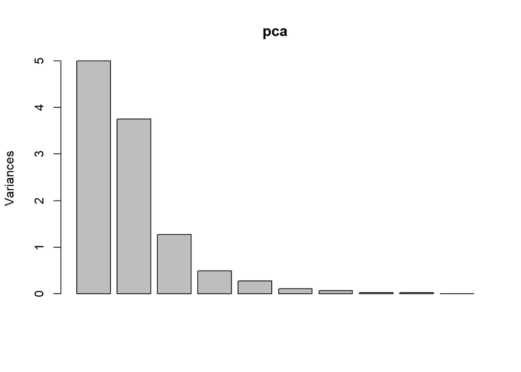

```r
# Running PCA on the stylistic word frequencies.
# Scaling is essential so highly frequent words (like 'the') don't mathematically dominate the variance.
pca <- prcomp(words, scale. = TRUE)

screeplot(pca)
```

Note that because the stopwords may have different variances, scaling the variables is appropriate so that no single word dominates the PCA only because of its scale.

1. Display a biplot of the PCA results. Interpret the positions of the novels and the directions of the stopword arrows. Do novels by the same author tend to appear close together, and which stopwords seem to contribute most to the separation between authors?

   **Hint:** Use `biplot()`.

**Show Answer**

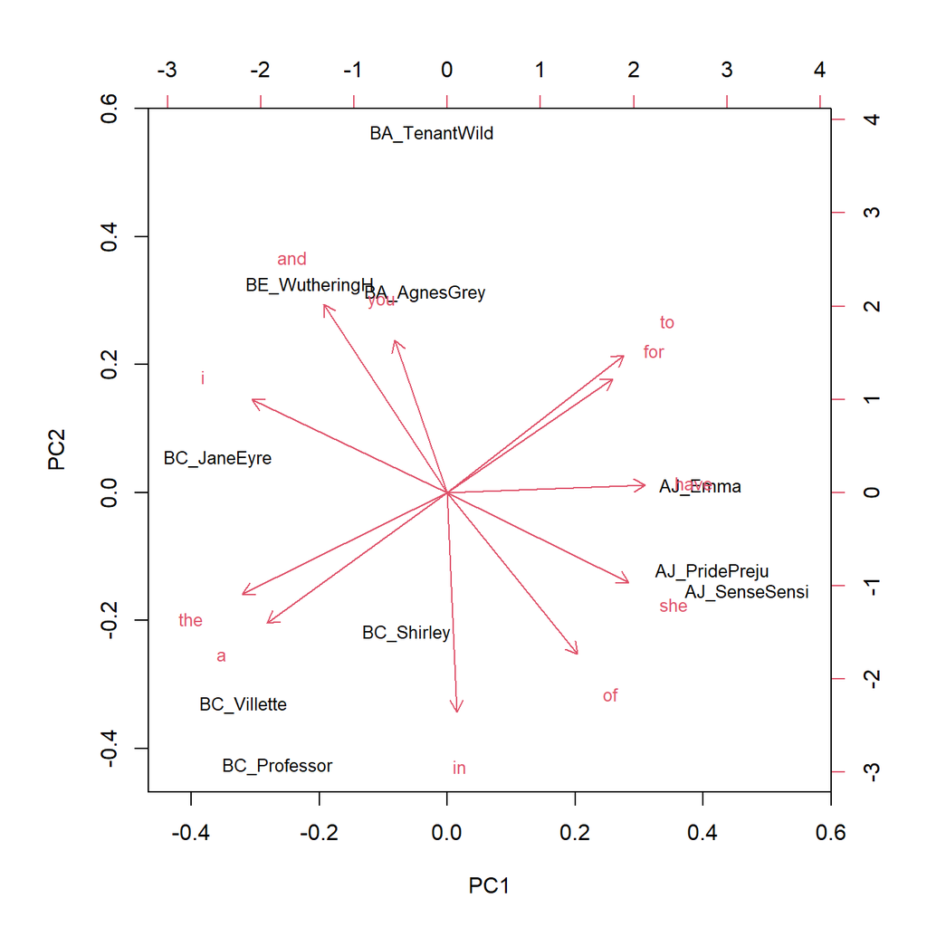

```r
# The biplot visualizes both the novels (points) and the words (arrows) in the same 2D principal component space
biplot(pca, cex = .8)
```

# Bonus: Eigenfaces

The dataset for this exercise is called `faces` and is available in the file `faces.RData`.

It contains 2410 face images. Each image is stored as grayscale values for 8064 pixels in a $96 \times 84$ image, with values ranging from 0 to 255.

The goal is to apply PCA to summarize these images with a smaller number of components. These principal components can be interpreted as typical facial patterns, also called *eigenfaces*.

1. Load this file into workspace with the function `load()`.

   **Hint:** Use the `load()` function.

**Show Answer**

```r
load("faces.RData")
```

2. To get some idea of what the data look like, display a summary columns of the first 5 columns (faces) of `faces`.

   **Hint:** Use `summary()` on the first 5 columns: `faces[, 1:5]`.

**Show Answer**

```r
# Inspecting pixel intensity values (0 to 255) for the first 5 images
summary(faces[, 1:5])
```

```
##        V1               V2              V3               V4
##  Min.   : 12.00   Min.   :  4.5   Min.   :  2.25   Min.   :  0.00
##  1st Qu.: 90.75   1st Qu.: 86.5   1st Qu.: 58.75   1st Qu.:  5.25
##  Median :114.75   Median :113.0   Median :104.25   Median :  8.75
##  Mean   :114.59   Mean   :116.5   Mean   :106.80   Mean   : 15.72
##  3rd Qu.:137.75   3rd Qu.:148.5   3rd Qu.:153.75   3rd Qu.: 13.75
##  Max.   :238.00   Max.   :247.0   Max.   :255.00   Max.   :255.00
##        V5
##  Min.   : 11.5
##  1st Qu.: 84.5
##  Median :107.9
##  Mean   :106.0
##  3rd Qu.:126.8
##  Max.   :211.2
```

**Show Answer**

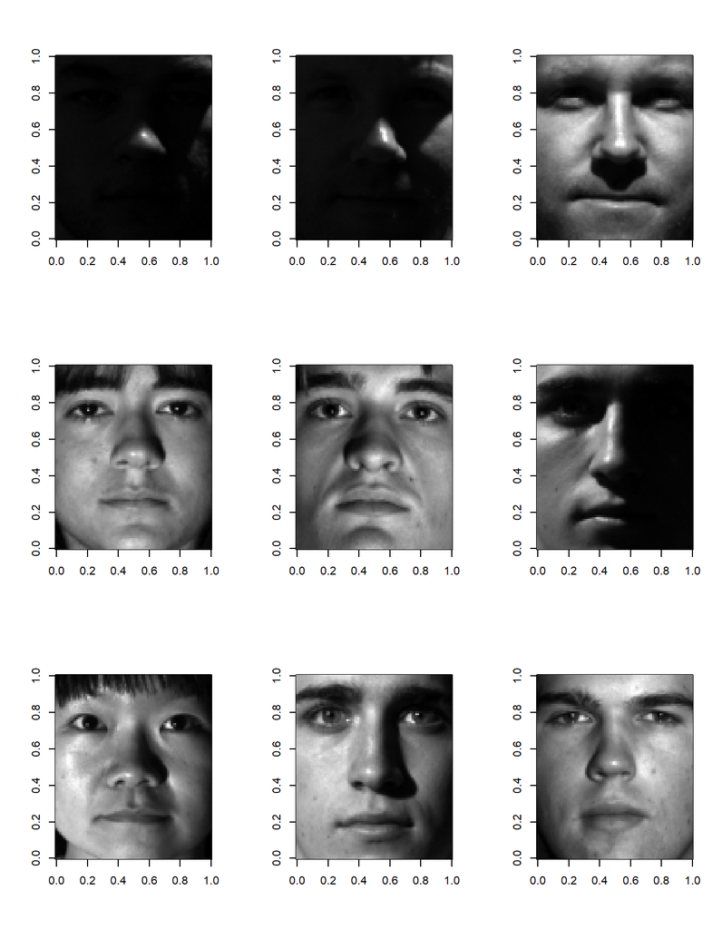

```r
# Reconstructing the 84x96 image matrices from the flattened vectors to visualize the actual faces
par(mfrow=c(3,3))
par(mfrow=c(3,3))
for(i in sample(1:2410, size=9)){
  face <- matrix(rev(faces[,i]), nrow = 84, ncol = 96)
  image(face, col = gray(0:255 / 255 ))
}
```

4. Perform a PCA on `faces` using `prcomp()` (may take a while), and save the result.

   **Hint:** Apply `prcomp()` directly to the `faces` data matrix.

**Show Answer**

```r
# Applying PCA to the pixel data to extract 'eigenfaces' (the most dominant structural facial patterns)
faces_pca <- prcomp(faces)
```

5. In the same way as exercise c, convert the first 9 components scores to 84 x 96 matrices, and display the images of the eigenfaces.

   **Hint:** Copy the logic from exercise c, but replace `faces[, i]` with `faces_pca$x[, i]` to plot the principal components instead of the raw images.

**Show Answer**

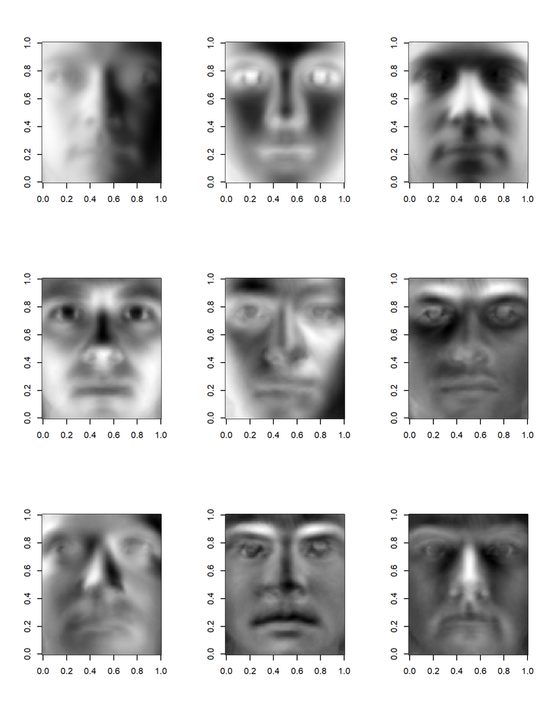

```r
# Visualizing the first 9 principal components as images.
# These represent the core visual building blocks (eigenfaces) of the entire dataset.
par(mfrow=c(3, 3))
for(i in 1:9){
  face <- matrix(rev(faces_pca$x[, i]), nrow = 84, ncol = 96)
  image(face, col = gray(0:255 / 255 ))
}
```

# Conclusion

In this lab, PCA was applied in several different contexts to show its flexibility as a tool for analyzing high-dimensional data.

For the `tumor` data, PCA was used as a feature extraction method: the original variables were replaced by a smaller number of principal component scores, which were then used as predictors in a logistic regression model. This illustrated that, although PCA itself is unsupervised, its scores can be useful in subsequent supervised prediction tasks.

For the `Profession` data, PCA helped uncover the main structure underlying the profession preference items. The rotated solution showed that PCA can improve interpretability and can recover meaningful latent dimensions that correspond closely to the intended personality types.

For the text data, PCA was applied to relative stopword frequencies in novels. This showed that PCA can also be used in text analysis to reveal stylistic similarities and differences between authors, even when using very common words with little direct semantic meaning.

Finally, in the bonus exercise on face images, PCA was used to summarize large numbers of correlated pixel values into a small number of components, leading to the idea of *eigenfaces*. This demonstrated how PCA can capture the dominant patterns in image data.

So, this lab showed that PCA is a powerful method for dimension reduction, visualization, interpretation, and feature extraction across a wide range of applications.

END OF LAB